# Econométrie Spatiale - Application sur l’Emploi en France

Author

Isabelle Cadoret

Téléchargement des packages

```r
pacman::p_load(knitr, vtable, dplyr, ggplot2,spdep, sf,readr,readxl,tmap,stringr,viridis,lattice )
```

## 1 Lecture des données et préparation des données

### 1.1 Source et description des données

Source :

https://www.insee.fr/fr/metadonnees/source/serie/s1162

https://www.insee.fr/fr/statistiques/2028584

Intitulé des séries :

- txcho: taux de chômage
- tx_act: taux d’activité
- part_act_1530: % des personnes en emploi de moins de 30 ans
- part_act_5064: % des personnes en emploi de plus de 50 ans
- part_act_peudip: % des personnes en emploi avec une faible qualification
- part_emp_pub: % des emplois dans le secteur public
- part_emp_ind: % des emplois dans le secteur industriel

### 1.2 Statistiques descriptives

```r
donnees_ze=read.csv("chomage.csv",sep=";",dec=".",header=TRUE, colClasses=c('character','character',rep('numeric',7)))
options(digits = 3)

kable(donnees_ze[1:20,], caption ="Emploi en France - source INSEE")
```

Emploi en France - source INSEE

| ze2010 | libelle_ze | txcho_2013 | tx_act | part_act_1530 | part_act_5064 | part_act_peudip | part_emp_pub | part_emp_ind |
| --- | --- | --- | --- | --- | --- | --- | --- | --- |
| 50 | Mont-de-Marsan | 7.8 | 73.2 | 20.2 | 27.1 | 19.6 | 38.7 | 15.70 |
| 51 | Alençon | 9.4 | 71.6 | 22.7 | 26.1 | 22.8 | 41.3 | 14.24 |
| 52 | Cosne - Clamecy | 9.4 | 70.2 | 20.5 | 29.1 | 24.4 | 37.4 | 16.05 |
| 53 | Mâcon | 7.5 | 76.3 | 21.6 | 25.1 | 21.8 | 33.7 | 17.81 |
| 54 | Nogent-le-Rotrou | 8.7 | 74.9 | 21.3 | 26.7 | 27.8 | 24.5 | 38.01 |
| 55 | Vallée de la Bresle - Vimeu | 10.5 | 70.4 | 22.3 | 24.8 | 32.1 | 21.9 | 45.85 |
| 56 | Roissy - Sud Picardie | 10.8 | 73.8 | 24.3 | 23.3 | 28.1 | 26.3 | 9.72 |
| 57 | Brive-la-Gaillarde | 9.1 | 73.8 | 19.2 | 28.2 | 18.4 | 30.0 | 20.97 |
| 59 | Avignon | 12.1 | 72.0 | 22.2 | 25.0 | 23.5 | 31.8 | 12.21 |
| 60 | Saint-Étienne | 9.9 | 71.7 | 23.3 | 24.6 | 20.1 | 34.1 | 21.31 |
| 61 | Toulouse | 10.1 | 74.4 | 23.9 | 22.5 | 14.6 | 30.8 | 14.12 |
| 1101 | Paris | 8.7 | 77.6 | 23.9 | 22.8 | 18.2 | 23.8 | 6.66 |
| 1102 | Marne-la-Vallée | 7.8 | 78.3 | 24.8 | 22.1 | 19.9 | 22.9 | 9.12 |
| 1103 | Coulommiers | 7.5 | 74.8 | 23.2 | 23.6 | 25.3 | 34.2 | 13.94 |
| 1104 | Meaux | 9.4 | 75.7 | 24.4 | 23.6 | 25.5 | 38.8 | 11.17 |
| 1105 | Melun | 8.1 | 75.7 | 23.5 | 23.9 | 20.8 | 38.5 | 13.01 |
| 1106 | Montereau-Fault-Yonne | 11.2 | 71.0 | 25.5 | 22.2 | 26.9 | 35.6 | 21.32 |
| 1107 | Nemours | 7.9 | 73.7 | 21.2 | 25.6 | 26.0 | 33.7 | 20.83 |
| 1108 | Provins | 9.2 | 73.7 | 23.3 | 24.9 | 28.1 | 43.2 | 14.28 |
| 1109 | Houdan | 4.9 | 75.5 | 16.7 | 29.1 | 14.3 | 36.1 | 9.64 |

```r
st(donnees_ze[,-c(1,2)])
```

Summary Statistics

| Variable | N | Mean | Std. Dev. | Min | Pctl. 25 | Pctl. 75 | Max |
| --- | --- | --- | --- | --- | --- | --- | --- |
| txcho_2013 | 297 | 10 | 2.4 | 4.9 | 8.3 | 11 | 18 |
| tx_act | 297 | 73 | 2.6 | 66 | 71 | 74 | 82 |
| part_act_1530 | 297 | 22 | 2 | 17 | 20 | 23 | 28 |
| part_act_5064 | 297 | 25 | 2.1 | 21 | 24 | 27 | 31 |
| part_act_peudip | 297 | 22 | 3.6 | 13 | 20 | 25 | 32 |
| part_emp_pub | 297 | 33 | 6.2 | 15 | 30 | 37 | 51 |
| part_emp_ind | 297 | 20 | 8.8 | 3.7 | 13 | 25 | 52 |

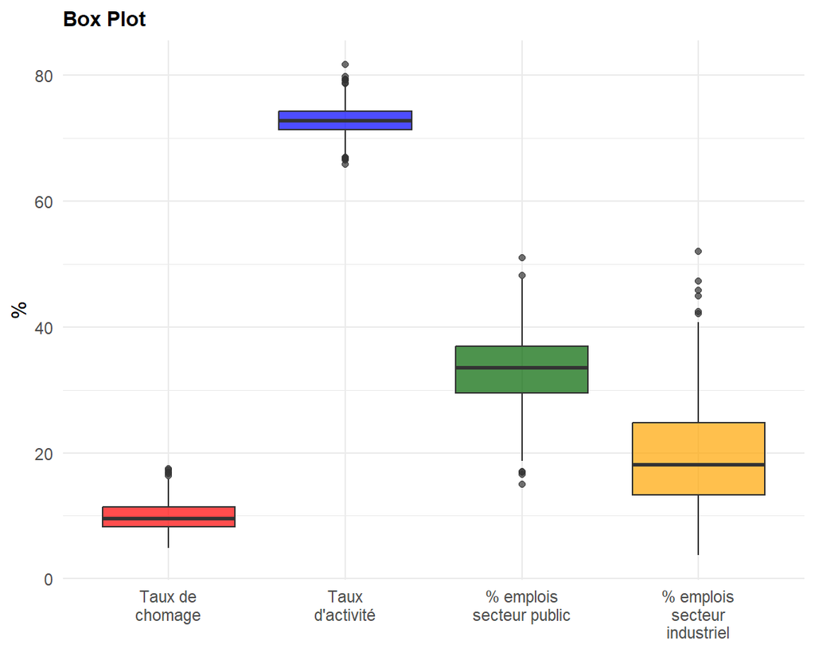

```r
library(ggplot2)
library(tidyr)
library(dplyr)

donnees_long <- donnees_ze %>%
  select(txcho_2013,tx_act, part_emp_pub, part_emp_ind) %>%
  pivot_longer(everything(), names_to = "variable", values_to = "valeur") %>%
  mutate(variable = factor(variable,
                           levels = c("txcho_2013","tx_act", "part_emp_pub", "part_emp_ind"),
                           labels = c("Taux de chomage","Taux d'activité",
                                      "% emplois secteur public",
                                      "% emplois secteur industriel")))

p2 <- ggplot(donnees_long, aes(x = variable, y = valeur, fill = variable)) +
  geom_boxplot(alpha = 0.7, show.legend = FALSE) +
  scale_fill_manual(values = c("red","blue", "darkgreen", "orange")) +
  labs(title = "Box Plot", x = NULL, y = "%") +
  theme_minimal() +
  theme(plot.title = element_text(size = 11, face = "bold"))

p2 +   scale_x_discrete(labels = scales::label_wrap(15))
```

## 2 Représentation cartographique des données

### 2.1 Téléchargement du fond de carte

Sources

https://www.insee.fr/fr/information/4652957

https://www.observatoire-des-territoires.gouv.fr/kiosque/panorama-des-zones-demploi

```r
map_ze<-st_read(dsn="zempl_2010.shp",layer= "zempl_2010")
class(map_ze)
```

```
[1] "sf"         "data.frame"
```

```r
st_crs(map_ze)
```

```
Coordinate Reference System: NA
```

```r
st_bbox(map_ze)
```

```
   xmin    ymin    xmax    ymax
  99226 6137164 1082671 7110480
```

```r
#valeurs qui correspondent système de coordonnées géographique Lambert-93 (EPSG:2154).

map_ze<-map_ze %>% st_set_crs(2154) #st_set_crs() déclare que les coordonnées sont exprimées dans le système de référence 2154


map_ze<-st_make_valid(map_ze) # précaution : répare les géométries invalides, qui ne respecte pas les règles de construction des polygones, d’un objet sf, sans changer le reste du tableau

dim(map_ze)
```

```
[1] 297   7
```

### 2.2 Représentation des données sur la carte

Il faut fusionner les données des 2 fichiers. Pour cela il faut un identifiant commun. Dans le fichier donnees_ze il s’agit de ze2010 et dans map_ze de Codgeo.

On vérifie tout d’abord la corresponsance des 2 ID.

```r
isTRUE(all.equal(donnees_ze$ze2010,as.character(map_ze$Codgeo)))
```

```
[1] FALSE
```

```r
head(map_ze$Codgeo)
```

```
[1] "0050" "0051" "0052" "0053" "0054" "0055"
```

```r
head(donnees_ze$ze2010)
```

```
[1] "50" "51" "52" "53" "54" "55"
```

```r
isTRUE(all.equal(donnees_ze$ze2010,as.character(map_ze$Codgeo)))
```

```
[1] FALSE
```

On constate qu’il y a une différence. Dans map_ze le code comporte 4 chiffres et dans donnees_ze certains ont 2 chiffres. On ajoute 00 dans donnees_ze pour avoir une correspondance exacte.

```r
for(i in 1:nrow(donnees_ze)){
  if(str_length(donnees_ze$ze2010[i])==2){
    donnees_ze$ze2010[i] <- str_c("00", donnees_ze$ze2010[i], sep="")
  }
}
head(donnees_ze$ze2010)
```

```
[1] "0050" "0051" "0052" "0053" "0054" "0055"
```

```r
isTRUE(all.equal(donnees_ze$ze2010,as.character(map_ze$Codgeo)))
```

```
[1] TRUE
```

Représentation du taux de chômage avec **ggplot**

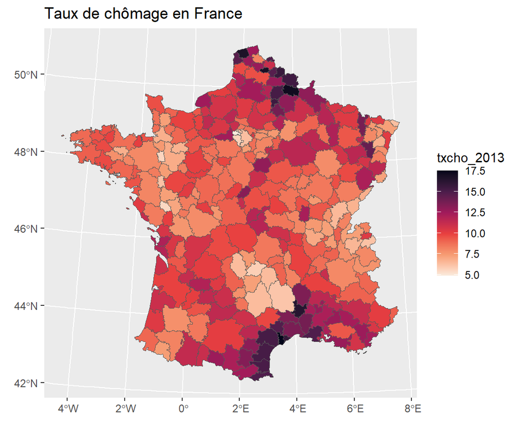

```r
colnames(donnees_ze)[1]<-"Codgeo"
map_ze <- left_join(map_ze, donnees_ze, by = "Codgeo")

## représentation de la série continu
ggplot(data = map_ze) +
  geom_sf(aes(fill = txcho_2013)) +scale_fill_viridis_c(option="rocket",begin = 1,end=0)+
 ggtitle("Taux de chômage en France")
```

```r
## représentation selon les quantiles
tx_quant <- quantile(map_ze$txcho_2013)
tx_quant
```

```
  0%  25%  50%  75% 100%
 4.9  8.3  9.6 11.4 17.5
```

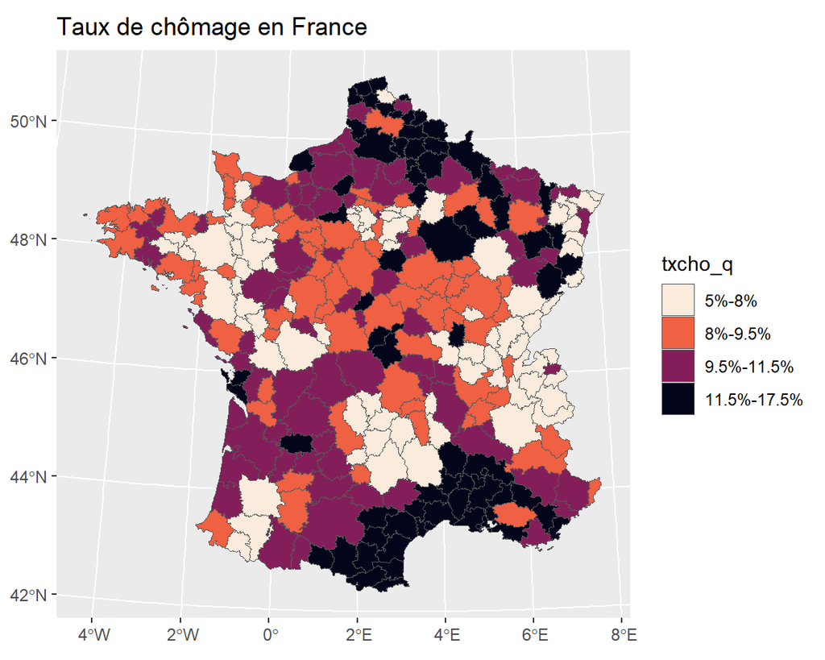

```r
map_ze$txcho_q <- cut(map_ze$txcho_2013,
                          breaks = tx_quant,
                          include.lowest = TRUE,
                          labels = c("5%-8%", "8%-9.5%", "9.5%-11.5%", "11.5%-17.5%"))


ggplot(data = map_ze) +
  geom_sf(aes(fill = txcho_q)) +scale_fill_viridis_d(option="rocket",begin = 1,end=0)+
 ggtitle("Taux de chômage en France")
```

## 3 Matrices de poids spatiales

Nous allons construire différentes formes de matrices de poids spatiales.

Représentation des centroïdes pour chaque zone géographique et Sauvegarde des centroïdes

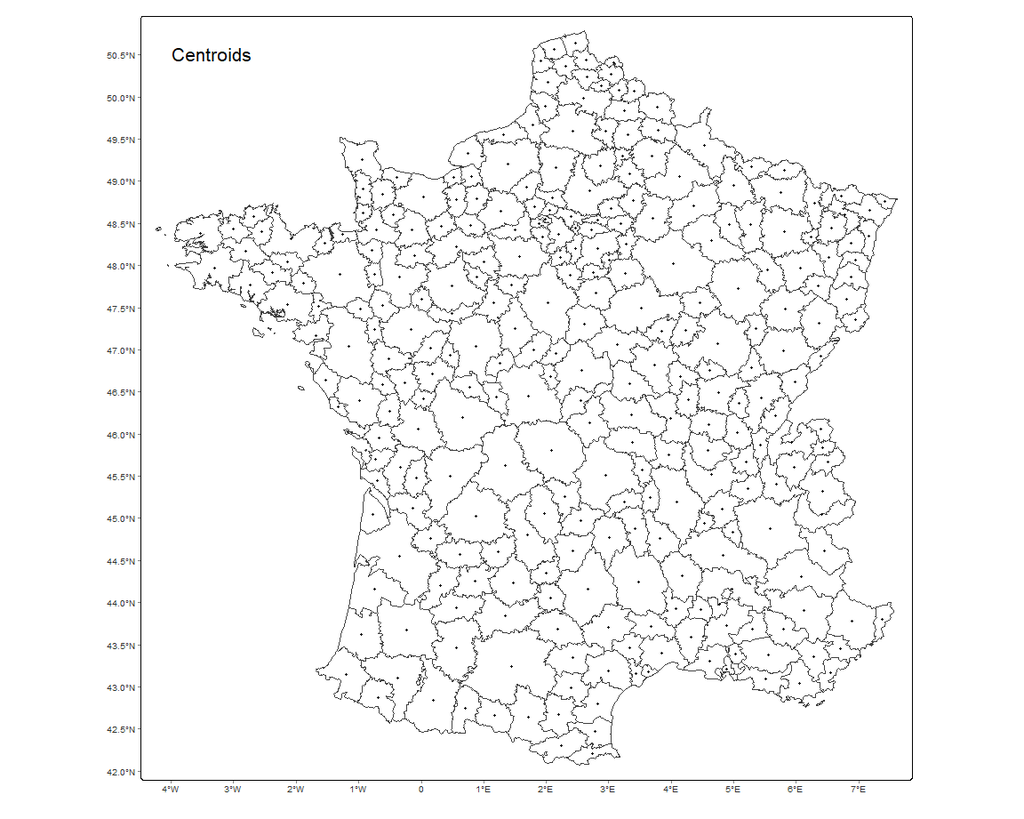

```r
tmap_mode("plot")
tm_shape(map_ze)+tm_polygons(col="white", border.col = "grey25")+
tm_graticules(lines = FALSE)+
  tm_shape(st_centroid(map_ze))+tm_dots(size = .2,col="red")+
  tm_layout(title ="Centroids",title.position = c('left', 'top'),scale=0.5)
```

```r
coor<-st_centroid(st_geometry(map_ze))
```

### 3.1 Matrice de contiguité

Utilisation de la fonction **poly2nb** pour définir les voisins, matrice de contiguité Queen ou Rook, Queens = 1 point commun, ROOK = 2 points communs

```r
mapC.nb<-poly2nb(map_ze,queen = TRUE)
summary(mapC.nb)
```

```
Neighbour list object:
Number of regions: 297
Number of nonzero links: 1582
Percentage nonzero weights: 1.79
Average number of links: 5.33
Link number distribution:

 1  2  3  4  5  6  7  8  9 10 11 13
 4  7 40 48 67 63 31 21 11  2  2  1
4 least connected regions:
102 137 205 286 with 1 link
1 most connected region:
180 with 13 links
```

```r
head(mapC.nb)
```

```
[[1]]
[1] 203 206 207 208 209 213 220 223

[[2]]
[1]   5  50  59  61  85  86  87 159 162

[[3]]
[1]  56  71  92  93  99 100

[[4]]
[1]  95  97  98 232 243

[[5]]
[1]   2  59  60  70 160 162

[[6]]
[1] 44 46 47 53 55
```

```r
class(mapC.nb)
```

```
[1] "nb"
```

Représentation des liens sur une carte

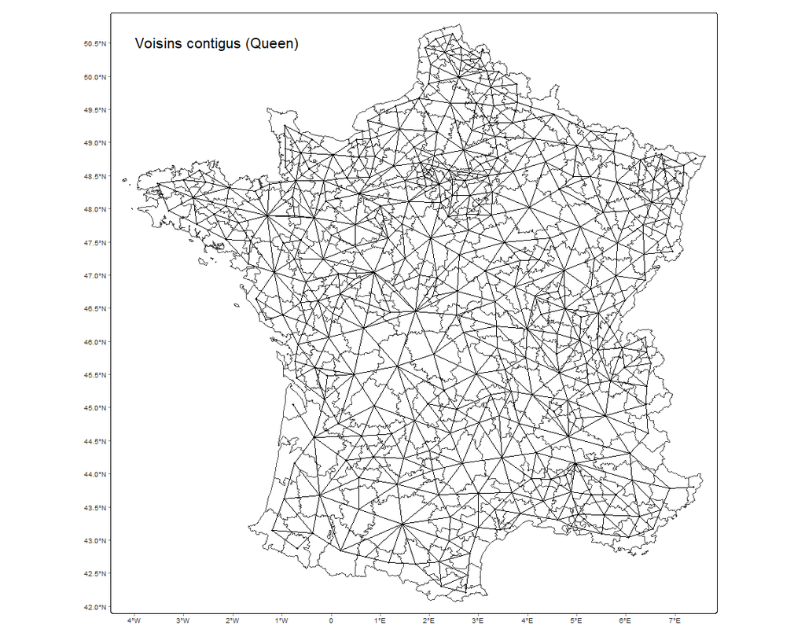

```r
tmap_mode("plot")
tm_shape(map_ze)+tm_polygons(col="white", border.col = "grey25")+
tm_graticules(lines = FALSE)+
  tm_shape(st_centroid(map_ze))+tm_dots(size = .2,col="red")+
  tm_shape(nb2lines(mapC.nb, coords=coor))+tm_lines(col="black", lwd=0.3)+
  tm_layout(title ="Voisins contigus (Queen)",title.position = c('left', 'top'),scale=0.5)
```

Avec la fonction **nb2listw** on crée la matrice de contiguité normalisée par ligne par défault

Options :

- style: style can take values “W”, “B”, “C”, “U”, “minmax” and “S”. B is the basic binary coding, W is row standardised (sums over all links to n), C is globally standardised (sums over all links to n), U is equal to C divided by the number of neighbours (sums over all links to unity), while S is the variance-stabilizing coding scheme proposed by Tiefelsdorf et al. 1999, p. 167-168 (sums over all links to n).
- zero.policy: FALSE (no island)

```r
cont.w<-nb2listw(mapC.nb,style="W")
summary(cont.w)
```

```
Characteristics of weights list object:
Neighbour list object:
Number of regions: 297
Number of nonzero links: 1582
Percentage nonzero weights: 1.79
Average number of links: 5.33
Link number distribution:

 1  2  3  4  5  6  7  8  9 10 11 13
 4  7 40 48 67 63 31 21 11  2  2  1
4 least connected regions:
102 137 205 286 with 1 link
1 most connected region:
180 with 13 links

Weights style: W
Weights constants summary:
    n    nn  S0  S1   S2
W 297 88209 297 122 1235
```

```r
class(cont.w)
```

```
[1] "listw" "nb"
```

### 3.2 Matrice des plus proches voisins

La fonction **knearneigh** permet de déterminer les plus proches voisins de chaque zone et la fonction **knn2b** convertit un objet knn (créé par knearneigh) en une liste de voisins de classe nb avec une liste de vecteurs entiers contenant les numéros des régions voisines.

```r
mapPPV2.knn<-knearneigh(coor,k=4)
head(mapPPV2.knn$nn)
```

```
     [,1] [,2] [,3] [,4]
[1,]  207  213  220  206
[2,]   87   85    5  160
[3,]   71   93   92   99
[4,]  243  232   97   95
[5,]  160    2   59   60
[6,]   46   53   47  116
```

```r
mapPPV2.nb<- knn2nb(mapPPV2.knn)
```

Représentation des liens

[figure not shown]

```r
tm_shape(map_ze)+tm_polygons(col="white", border.col = "grey25")+
tm_graticules(lines = FALSE)+
  tm_shape(st_centroid(map_ze))+tm_dots(size = .2,col="red")+
  tm_shape(nb2lines(mapPPV2.nb, coords=coor))+tm_lines(col="black", lwd=0.3)+
  tm_layout(title ="2 plus proches voisins",title.position = c('left', 'top'),scale=0.5)
```

```r
PPV2.w<-nb2listw(mapPPV2.nb,style="W")
```

### 3.3 Matrice de poids basée sur la distance euclienne

La fonction **nbdists** montre la distance maximale par rapport aux voisins les plus proches. Ici la distance moyenne est de 33.5 km

```r
nb1 <- knn2nb(knearneigh(coor, k = 1))
dsts <- unlist(nbdists(nb1, coor))
summary(dsts)
```

```
   Min. 1st Qu.  Median    Mean 3rd Qu.    Max.
  10489   28505   32792   33502   38991   67494
```

La fonction **dnearneigh** donne les voisin à moins de 100km

```r
nb100km <- dnearneigh(x = st_centroid(map_ze), d1 = 0, d2 = 100000)
head(nb100km)
```

```
[[1]]
 [1] 203 206 207 208 209 211 212 213 220 223

[[2]]
 [1]   5  49  50  51  59  60  61  70  76  77  78  79  85  86  87 158 159 160 161
[20] 162 163

[[3]]
 [1]  56  57  58  63  71  72  91  92  93  94  99 100 101 254

[[4]]
 [1]  88  94  95  96  97  98 145 146 147 231 232 233 239 242 243 244

[[5]]
 [1]   2  20  21  23  24  49  50  59  60  61  68  70  78  85  87 159 160 161 162
[20] 163

[[6]]
 [1]  30  44  46  47  48  52  53  54  55 110 112 113 115 116
```

Représentation des voisins distants de moins de 100km

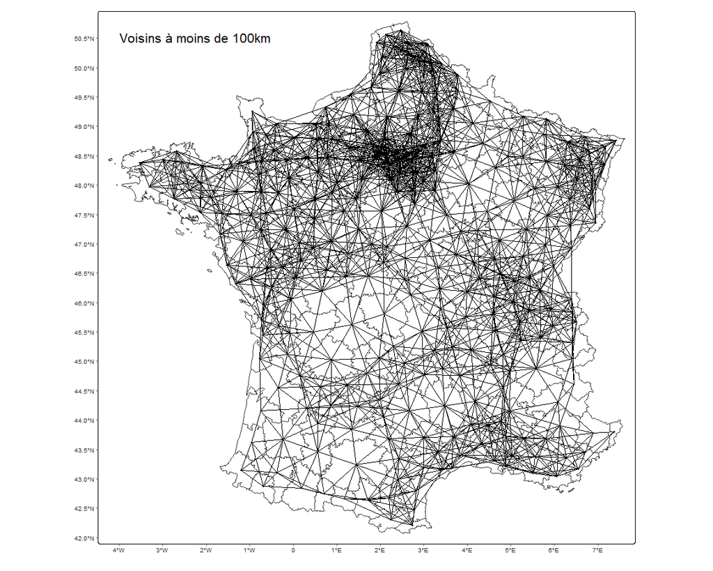

```r
tm_shape(map_ze)+tm_polygons(col="white", border.col = "grey25")+
tm_graticules(lines = FALSE)+
  tm_shape(st_centroid(map_ze))+tm_dots(size = .2,col="red")+
  tm_shape(nb2lines(nb100km, coords=coor))+tm_lines(col="black", lwd=0.3)+
  tm_layout(title ="Voisins à moins de 100km",title.position = c('left', 'top'),scale=0.5)
```

Calcul des distances avec la fonction **nbdists,** et de la distance inverse avec gamma =1

```r
dists <- nbdists(nb100km, coor)

ids <- lapply(dists, function(x){1/x})
nb100km.ids.w <- nb2listw(nb100km, glist = ids, style = "W")
```

Calcul des distances et de la distance inverse avec gamma =2

```r
ids2 <- lapply(dists, function(x){1/(x*x)})
nb100km.ids2.w <- nb2listw(nb100km, glist = ids2, style = "W")
```

## 4 Analyse de l’autocorrélation spatiale

### 4.1 Création du spatial lag avec la matrice de contiguité normalisée

La fonction attributes vérifie que les ID sont dans “neighbours”” et weights dans “weights”

```r
attributes(cont.w)
```

```
$names
[1] "style"      "neighbours" "weights"

$class
[1] "listw" "nb"

$region.id
  [1] "1"   "2"   "3"   "4"   "5"   "6"   "7"   "8"   "9"   "10"  "11"  "12"
 [13] "13"  "14"  "15"  "16"  "17"  "18"  "19"  "20"  "21"  "22"  "23"  "24"
 [25] "25"  "26"  "27"  "28"  "29"  "30"  "31"  "32"  "33"  "34"  "35"  "36"
 [37] "37"  "38"  "39"  "40"  "41"  "42"  "43"  "44"  "45"  "46"  "47"  "48"
 [49] "49"  "50"  "51"  "52"  "53"  "54"  "55"  "56"  "57"  "58"  "59"  "60"
 [61] "61"  "62"  "63"  "64"  "65"  "66"  "67"  "68"  "69"  "70"  "71"  "72"
 [73] "73"  "74"  "75"  "76"  "77"  "78"  "79"  "80"  "81"  "82"  "83"  "84"
 [85] "85"  "86"  "87"  "88"  "89"  "90"  "91"  "92"  "93"  "94"  "95"  "96"
```

[output cut: 23 more lines]

```r
x_chom <- cbind(donnees_ze$txcho_2013)
wx_chom <- lag.listw(cont.w,x_chom) #spatial lag
```

Vérification pour ID=1

```r
cont.w$neighbours[1]
```

```
[[1]]
[1] 203 206 207 208 209 213 220 223
```

```r
cont.w$weights[1]
```

```
[[1]]
[1] 0.125 0.125 0.125 0.125 0.125 0.125 0.125 0.125
```

```r
(x_chom[203,] + x_chom[206,] + x_chom[207,] + x_chom[208,] + x_chom[209,] + x_chom[213,] + x_chom[220,] + x_chom[223,] )/8.0
```

```
[1] 9.84
```

```r
wx_chom[1,]
```

```
[1] 9.84
```

Comparaison de x_chom et wx_chom

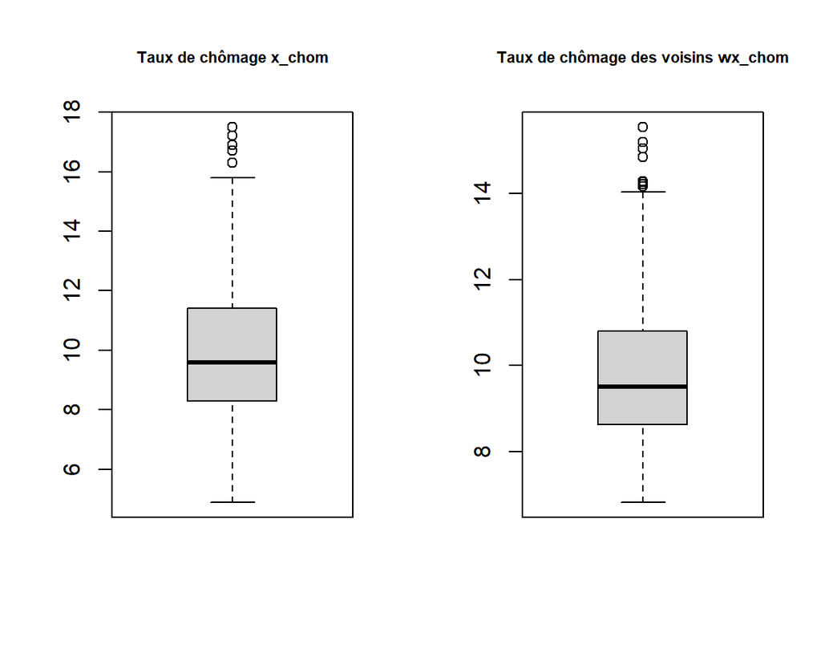

```r
par(mfrow=c(1,2),cex.main=0.7)
boxplot.matrix(x_chom,main="Taux de chômage x_chom")
boxplot.matrix(wx_chom,main="Taux de chômage des voisins wx_chom")
```

### 4.2 Indice de Moran calculé avec la matrice de contiguité

L’indice de Moran mesure la corrélation entre X et WX, on peut retrouver cet indice à partir d’une régression simple de WX en fonction de X

```r
lm_moran <- lm(wx_chom~x_chom)
summary(lm_moran)
```

```
Call:
lm(formula = wx_chom ~ x_chom)

Residuals:
   Min     1Q Median     3Q    Max
-3.061 -0.731 -0.050  0.623  3.456

Coefficients:
            Estimate Std. Error t value Pr(>|t|)
(Intercept)   4.2626     0.2914    14.6   <2e-16 ***
x_chom        0.5668     0.0284    19.9   <2e-16 ***
---
Signif. codes:  0 '***' 0.001 '**' 0.01 '*' 0.05 '.' 0.1 ' ' 1

Residual standard error: 1.16 on 295 degrees of freedom
Multiple R-squared:  0.574, Adjusted R-squared:  0.573
F-statistic:  397 on 1 and 295 DF,  p-value: <2e-16
```

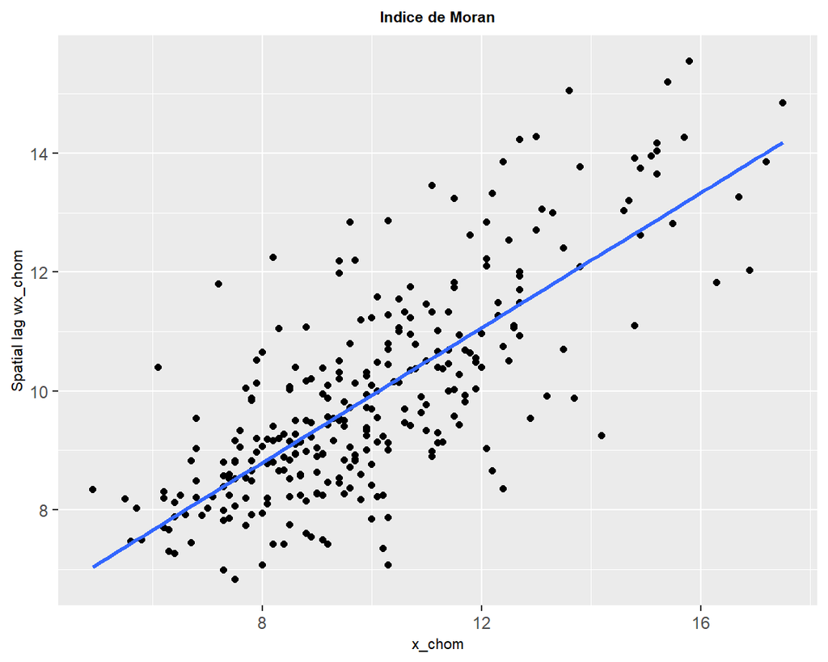

```r
ggplot(data = map_ze, mapping = aes(x = x_chom, y = wx_chom )) + geom_point()+labs(title = " Indice de Moran ", y = " Spatial lag wx_chom " , x ="x_chom") + theme(plot.title = element_text(color = "black", size = 8, face = "bold",hjust = 0.5),  axis.title.x = element_text(color = "black", size = 8, hjust = 0.5),
  axis.title.y = element_text(color = "black", size = 8, hjust = 0.5)) + geom_smooth(method="lm", se=FALSE)
```

Les fonctions qui permettent d’obtenir l’indice de Moran sont les fonctions **moran.test** and **moran.mc** avec l’option alternative = **greate**r (I>E(I) positively autocorrelated) / **less** (I<E(I), negatively autocorrelated) ,**two.sided** (I#E(I), autocorrelated) et l’option randomisation = **FALSE** (under normality) / **TRUE**

La fonction **moran.test** a une option randomisation, la différence porte sur le calcul de la variance de I elle est calculée sous l’hypothèse de randomisation si TRUE et si FALSE sou sl’hypothèse de normalité.

La fonction **moran.mc** effectue des permutations.

Dans l’exemple, l’autocorrélation est plutôt positive aussi on choist l’alternative greater

**Application de moran.test avec randomisation= FALSE**

- données non centrées

```r
morantest_cho_cont<- moran.test(donnees_ze$txcho_2013,cont.w,randomisation=FALSE,alternative="greater")
morantest_cho_cont
```

```
    Moran I test under normality

data:  donnees_ze$txcho_2013
weights: cont.w

Moran I statistic standard deviate = 15, p-value <2e-16
alternative hypothesis: greater
sample estimates:
Moran I statistic       Expectation          Variance
          0.56681          -0.00338           0.00136
```

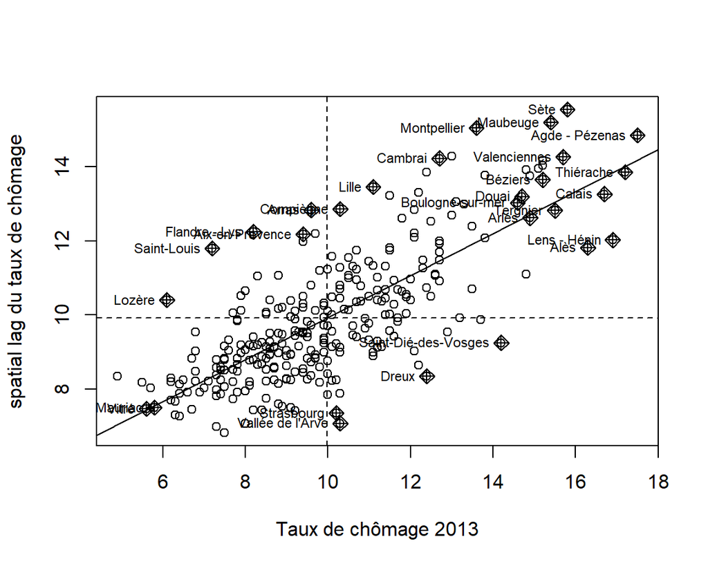

```r
moran.plot(x=donnees_ze$txcho_2013,cont.w,xlab="Taux de chômage 2013",ylab="spatial lag du taux de chômage",labels=as.character(donnees_ze$libelle_ze))
```

- données centrées

```r
donnees_ze$txcho_2013c<-donnees_ze$txcho_2013-mean(donnees_ze$txcho_2013)
morantest_cho_cont_c<- moran.test(donnees_ze$txcho_2013c,cont.w,randomisation=FALSE,alternative="greater")
morantest_cho_cont_c
```

```
    Moran I test under normality

data:  donnees_ze$txcho_2013c
weights: cont.w

Moran I statistic standard deviate = 15, p-value <2e-16
alternative hypothesis: greater
sample estimates:
Moran I statistic       Expectation          Variance
          0.56681          -0.00338           0.00136
```

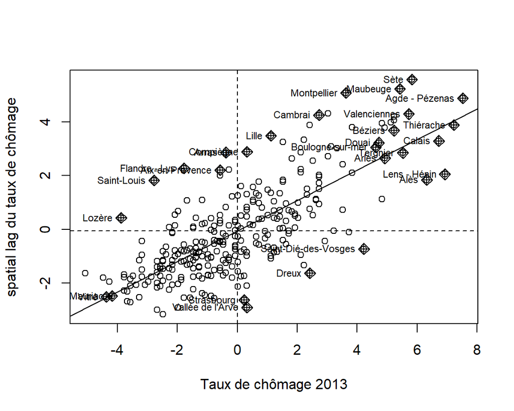

```r
moran.plot(x=donnees_ze$txcho_2013c,cont.w,xlab="Taux de chômage 2013",ylab="spatial lag du taux de chômage",labels=as.character(donnees_ze$libelle_ze))
```

**Application de moran.test avec randomisation = TRUE**

```r
morantest_cho_cont_cp<- moran.test(donnees_ze$txcho_2013c,cont.w,randomisation=TRUE,alternative="greater")
morantest_cho_cont_cp
```

```
    Moran I test under randomisation

data:  donnees_ze$txcho_2013c
weights: cont.w

Moran I statistic standard deviate = 15, p-value <2e-16
alternative hypothesis: greater
sample estimates:
Moran I statistic       Expectation          Variance
          0.56681          -0.00338           0.00135
```

**Application de moran.mc**

```r
set.seed(130)
morantest_cho_cont_cm <- moran.mc(donnees_ze$txcho_2013c,cont.w,999,alternative="greater")
#Observed value = 0.173645208
#no permutation give a value greater than 0.56681 L=0
#pour L=0, p_min=L+1/K+1 = 0+1/(999+1)=0.0001
morantest_cho_cont_cm
```

```
    Monte-Carlo simulation of Moran I

data:  donnees_ze$txcho_2013c
weights: cont.w
number of simulations + 1: 1000

statistic = 0.56681, observed rank = 1000, p-value = 0.001
alternative hypothesis: greater
```

### 4.3 LISA, les indicateurs locaux d’autocorrélation spatiale

Utilisation de la fonction **localmoran**

- données non centrées

```r
locm <-localmoran(donnees_ze$txcho_2013, cont.w)
head(locm)
```

```
      Ii      E.Ii  Var.Ii  Z.Ii Pr(z != E(Ii))
1 0.0536 -0.002865 0.10353 0.176          0.861
2 0.0455 -0.000200 0.00643 0.570          0.568
3 0.0473 -0.000200 0.00974 0.481          0.631
4 0.5213 -0.003710 0.21655 1.128          0.259
5 0.1886 -0.000985 0.04786 0.866          0.386
6 0.1021 -0.000167 0.00977 1.034          0.301
```

```r
summary(locm)
```

```
       Ii                E.Ii               Var.Ii              Z.Ii
 Min.   :-0.90771   Min.   :-3.43e-02   Min.   :0.000014   Min.   :-3.673
 1st Qu.: 0.00864   1st Qu.:-4.02e-03   1st Qu.:0.015479   1st Qu.: 0.137
 Median : 0.21013   Median :-1.41e-03   Median :0.082390   Median : 0.988
 Mean   : 0.56681   Mean   :-3.38e-03   Mean   :0.241536   Mean   : 0.985
 3rd Qu.: 0.71993   3rd Qu.:-3.18e-04   3rd Qu.:0.234332   3rd Qu.: 1.762
 Max.   : 6.57504   Max.   :-3.80e-07   Max.   :4.127702   Max.   : 5.333
 Pr(z != E(Ii))
 Min.   :1.00e-07
 1st Qu.:5.87e-02
 Median :2.62e-01
 Mean   :3.35e-01
 3rd Qu.:5.86e-01
 Max.   :9.83e-01
```

- données centrées

```r
locmc <-localmoran(donnees_ze$txcho_2013c, cont.w)
head(locmc)
```

```
      Ii      E.Ii  Var.Ii  Z.Ii Pr(z != E(Ii))
1 0.0536 -0.002865 0.10353 0.176          0.861
2 0.0455 -0.000200 0.00643 0.570          0.568
3 0.0473 -0.000200 0.00974 0.481          0.631
4 0.5213 -0.003710 0.21655 1.128          0.259
5 0.1886 -0.000985 0.04786 0.866          0.386
6 0.1021 -0.000167 0.00977 1.034          0.301
```

```r
summary(locmc)
```

```
       Ii                E.Ii               Var.Ii              Z.Ii
 Min.   :-0.90771   Min.   :-3.43e-02   Min.   :0.000014   Min.   :-3.673
 1st Qu.: 0.00864   1st Qu.:-4.02e-03   1st Qu.:0.015479   1st Qu.: 0.137
 Median : 0.21013   Median :-1.41e-03   Median :0.082390   Median : 0.988
 Mean   : 0.56681   Mean   :-3.38e-03   Mean   :0.241536   Mean   : 0.985
 3rd Qu.: 0.71993   3rd Qu.:-3.18e-04   3rd Qu.:0.234332   3rd Qu.: 1.762
 Max.   : 6.57504   Max.   :-3.80e-07   Max.   :4.127702   Max.   : 5.333
 Pr(z != E(Ii))
 Min.   :1.00e-07
 1st Qu.:5.87e-02
 Median :2.62e-01
 Mean   :3.35e-01
 3rd Qu.:5.86e-01
 Max.   :9.83e-01
```

Egalité du I de moran et de la somme des I locaux pondéré

```r
all.equal(sum(locmc[,1])/Szero(cont.w), unname(moran.test(donnees_ze$txcho_2013c, cont.w)$estimate[1]))
```

```
[1] TRUE
```

### 4.4 Cartographie des indices locaux de Moran sur données centrées

- Sans tenir compte de la significativité

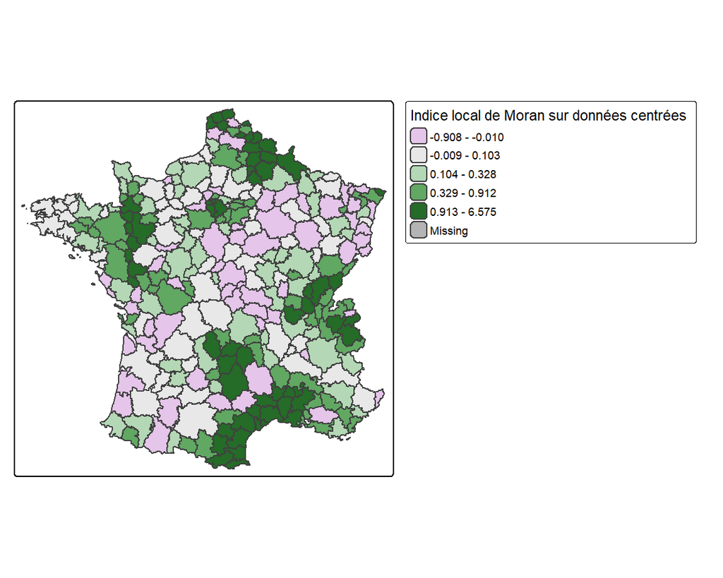

```r
moran.map <- cbind(map_ze, locmc)
tm_shape(moran.map) +
  tm_fill(col = "Ii",
          style = "quantile",
          title = "Indice local de Moran sur données centrées")
```

- Avec la significativité

  Définition des cadrants, on centre les indices locaux par rapport à leur moyenne et on définit un niveau de significativité (ici = 10%)

```r
x_chomc <- cbind(donnees_ze$txcho_2013c)
wx_chomc <- lag.listw(cont.w,x_chomc) #spatial lag

quadrant <- vector(mode="numeric",length=nrow(locm))
signif <- 0.1

quadrant[x_chomc>0 & wx_chomc>0 & locmc[,5]<signif] <- 4  #High-High
quadrant[x_chomc <0 & wx_chomc<0  & locmc[,5]<signif] <- 1 #Low-Low
quadrant[x_chomc<0 & wx_chomc>0  & locmc[,5]<signif] <- 2  #Low_High
quadrant[x_chomc >0 & wx_chomc<0 & locmc[,5]<signif] <- 3 #High-Low
quadrant[locmc[,5]>signif] <- 0  #insignificant

table(quadrant)
```

```
quadrant
  0   1   2   3   4
196  46   5   7  43
```

```r
verif <- cbind(quadrant, locmc[,5])
#verif
```

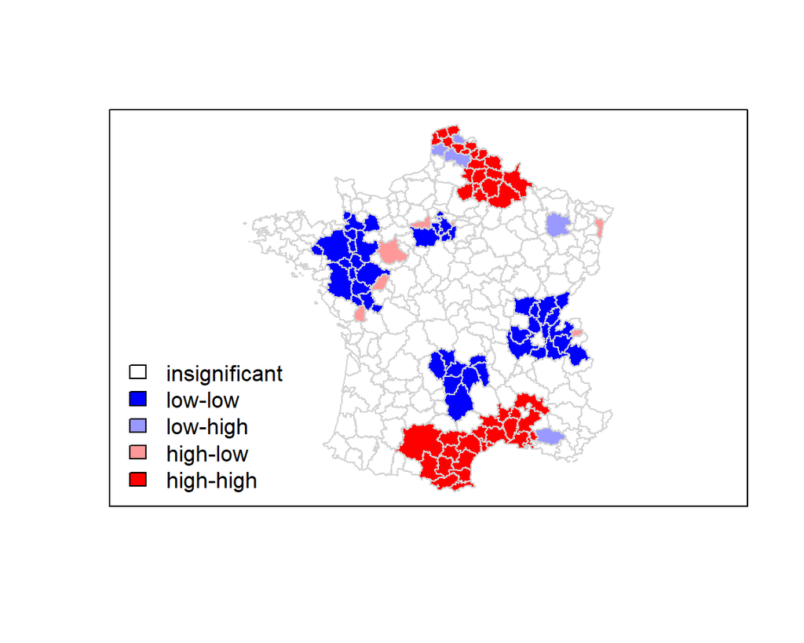

```r
brks <- c(0,1,2,3,4)
colors <- c("white","blue",rgb(0,0,1,alpha=0.4),rgb(1,0,0,alpha=0.4),"red")
plot(st_geometry(map_ze),border="lightgray",col=colors[findInterval(quadrant,brks,all.inside=FALSE)])
box()
legend("bottomleft", legend = c("insignificant","low-low","low-high","high-low","high-high"),
       fill=colors,bty="n")
```

## 5 Indice de Geary - test d’autocorrélation spatiale

Utilisation comme pour l’indice de Moran de 2 fonctions : **geary.test** et **geary.mc**

**Application de geary.test avec randomisation = FALSE**

```r
geary.test(donnees_ze$txcho_2013,cont.w, randomisation=FALSE, zero.policy=NULL,
    alternative="greater")
```

```
    Geary C test under normality

data:  donnees_ze$txcho_2013
weights: cont.w

Geary C statistic standard deviate = 15, p-value <2e-16
alternative hypothesis: Expectation greater than statistic
sample estimates:
Geary C statistic       Expectation          Variance
          0.40008           1.00000           0.00161
```

**Application de geary.test avec randomisation = TRUE**

```r
geary.test(donnees_ze$txcho_2013,cont.w, randomisation=TRUE, zero.policy=NULL,
    alternative="greater")
```

```
    Geary C test under randomisation

data:  donnees_ze$txcho_2013
weights: cont.w

Geary C statistic standard deviate = 15, p-value <2e-16
alternative hypothesis: Expectation greater than statistic
sample estimates:
Geary C statistic       Expectation          Variance
          0.40008           1.00000           0.00166
```

**Application de geary.mc**

```r
set.seed(135)
geary.mc(donnees_ze$txcho_2013,cont.w, nsim=99, zero.policy=NULL, alternative="greater",
return_boot=FALSE)
```

```
    Monte-Carlo simulation of Geary C

data:  donnees_ze$txcho_2013
weights: cont.w
number of simulations + 1: 100

statistic = 0.40008, observed rank = 1, p-value = 0.01
alternative hypothesis: greater
```